# Segmenting and Clustering Neighborhoods in Berlin

## East and West Berlin - 30 years after the Berlin Wall came down

#### 6. Conclusion

### 1. Introduction

It is now 30 years ago, that the Berlin Wall came down and the two parts of Berlin, East and West were re-unified again. The re-unification of Germany brought together two very different political systems, societies and infrastructure leading to a long period of growing together.

An interesting question, both, from a historical and sociological view is, whether there are still quantifiable differences between East and West, e.g., in the neighborhoods of Berlin?

More precisely:

**1. Is there (still) a difference between neighborhoods located in East and West Berlin?**

**2. If yes, what are the key characteristics of neighborhoods located in of East and West Berlin?**

To answer this questions, location data of the 12 borrows and 96 neighborhoods of Berlin are used to get information about the top 10 venues for each neighborhood. All neighborhoods will be clustered (*k*-means) based on similarities in their venue categories. Theses clusters will visualized on a map. Finally, the distribution of East and West Berlin neighborhood across cluster will be analyzed.

The target audience of this projects are historians and sociologists as well as local politicians and city planners. This project will provide them valuable insights in potential structural differences in the Berlin neighborhoods allowing them to assess the re-unification process and help make local decision regarding city planning.

### 2. Data

The project will use the following data and sources:

1. List of all neighborhoods and boroughs in Berlin (Wikipedia: https://de.wikipedia.org/wiki/Verwaltungsgliederung_Berlins)
1. Former boroughs of East Berlin (Wikipedia: https://en.wikipedia.org/wiki/East_Berlin)
1. Newly created and renamed boroughs after re-unification (Wikipedia:https://de.wikipedia.org/wiki/Verwaltungsgliederung_Berlins)

   Friedrichshain-Kreuzberg: Two neighborhoods - Friedrichshain (East) and Kreuzberg (West)

   Mitte: Six neighborhoods - Mitte (East), Tiergarten (West), Wedding (West), Gesundbrunnen (West), Moabit (west), Hansaviertel (West)

   Marzahn-Hellersdorf: Fusion of two boroughs - Marzahn (East) and Hellersdorf (East)

   Pankow: Fusion of three boroughs - Pankow (East), Prenzlauer Berg (East), Weissensee (East)

   Lichtenberg: Fusion of two boroughs - Lichtenberg (East), Hohenschönhausen
1. Location data of all Berlin neighborhoods (geopy) (e.g., latitude, longitude: 52.530102, 13.342542)
1. Location data (geojsn file) of all Berlin boroughs (https://tsb-opendata.s3.eu-central-1.amazonaws.com/ortsteile/lor_ortsteile.geojson)
1. The top 10 venues and its categories for all 96 neighborhoods in Berlin within a radius of 500 meters (FourSquare)

   (e.g., Restaurants, Museum, Theater - https://developer.foursquare.com/docs/resources/categories)

### 3. Methodology

#### 3.1. Create dataframe of all Berlin neighborhoods

Create a dataframe of all Berlin neighborhoods - including infromation about borough, location (longitude and latitude) as well as the part of Berlin (West or East). The dataframe is callled **berlin_df**.

First, extract neighborhood and borough data from data source 1 (see Data section) nad check data: should cover 96 neighborhoods and 12 boroughs

Second, get list of boroughs in former East Berlin from data soruce 2. Extract neighborhood data and rename columns. Add colum 'Berlin' to indicate part of Berlin - in this case 'East'. Rename former East Berlin borougs according to current names of Berlin borougs. Delete old names and remove former boroughs, which are now neighborhoods of a new borough (data source 3).

Third, using the dataframe of with the names of all 96 neighborhoods, the coordinates of Berlin neighborhoods are determined with the geolocator function. To avoid time-outs requests are split into 5 packages.

The neighboorhood location data is merged with the list of East Berlin boroughs; West Berlin neighborhoods are labelled with 'West'. Finally, the labeling for the two East Berlin neighborhoods now beloinging to a West Berlin borough is adjusted to 'East'.

#### 3.2. Create a map of the Berlin neighborhoods

Add column 'Color' to the dataframe for coloring East and West on map differenly. Download Berlin neighborhood geojson file (data source 5). Then generate a choropleth map using the part of Berlin ('East', 'West') and superimpose the location of all 96 neighborhoods on top.

#### 3.3. Get top venues for all neighborhoods

Create a function to process all the neighborhoods in Berlin using FourSuare: The top 10 venues and their categories for all 96 neighborhoods in Berlin within a radius of 500 meters. Create a new dataframe called berlin_venues. Run function and check how many venues are returned for each neighborhood and how many unique categories are there. Next, analyze each neighborhodd and create a profile along the unique categories extracted. Group rows by neighborhood and by taking the mean of the frequency of occurrence of each category. Finally, **print each neighborhood along with the top 10 most common venues**.

Write a function to sort the venues in descending order and create a new dataframe and display the top 10 venues for each neighborhood: **neighborhoods_venues_sorted**.

#### 3.4. Cluster neighborhoods using *k-means*

Run *k*-means to cluster the neighborhood into 5 clusters. Then create a new dataframe that includes the cluster as well as the top 10 venues for each neighborhood: **berlin_merged**. Check the cluster labels and assign neighborhoods with Cluster Label 'NaN' to new cluster 5. Finally calculate the ratio of East neighborhoods per cluster (count of East neighborhoods per cluster devided by total count of neighborhoods (East and West) per cluster)

#### 3.5. Visualize the resulting clusters on a map

### 4. Results

#### 4.1. Dataframe of all Berlin neighborhoods

The resulting dataframe berlin_df comprises all relevant information for the 96 neighborhoods and 12 borrows of Berlin. There are 45 neighborhoods in East Berlin belonging to 6 boroughs. There are 51 neighborhoods in West Berlin belonging to 8 boroughs. Below the 'count'-analyis of the **berlin_df** dataframe is shown:

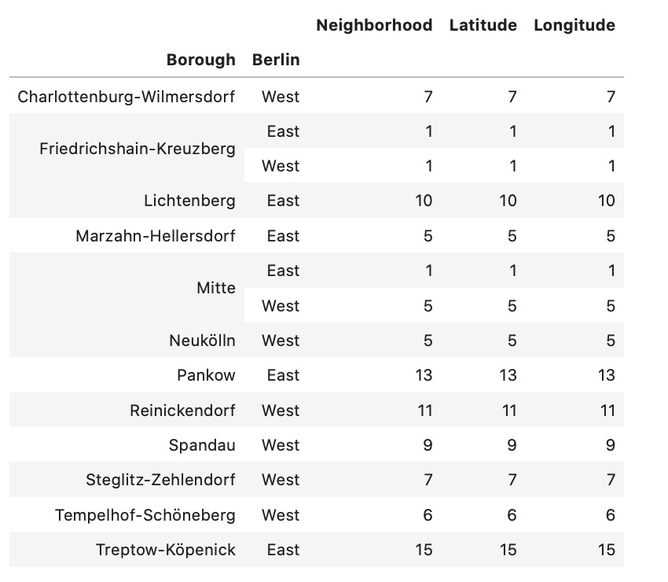

#### 4.2. Map of the Berlin neighborhoods

The map shows the 96 neighborhoods across East (red) and West (yellow) Berlin.

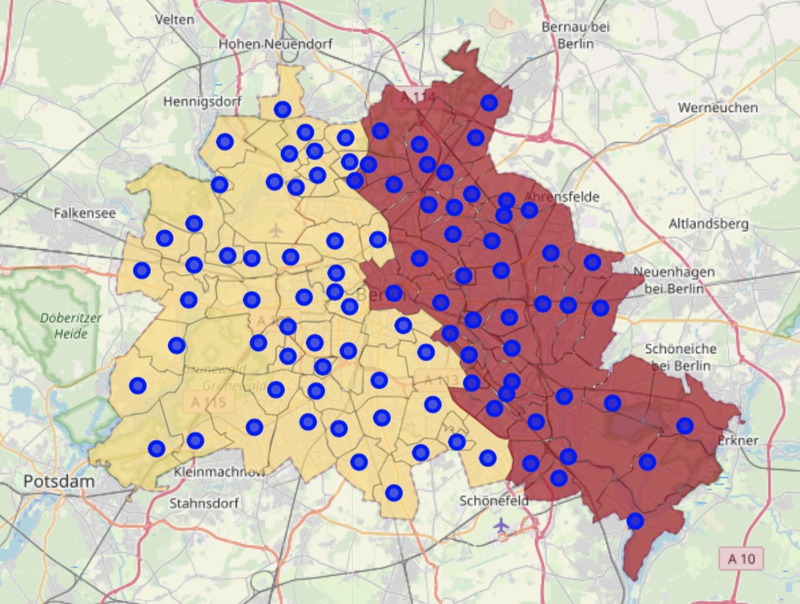

#### 4.3. Top 10 venues for all neighborhoods

Using FourSquare, 1170 venues can be downloaded covering 215 different venue categories. The TOP 10 for each neighborhood are (2 examples shown):

----Adlershof---- venue freq 0 Bank 0.14 1 Trattoria/Osteria 0.14 2 Insurance Office 0.14 3 Italian Restaurant 0.14 4 Greek Restaurant 0.14 5 Steakhouse 0.14 6 Supermarket 0.14 7 Opera House 0.00 8 Nightclub 0.00 9 Nature Preserve 0.00

----Alt-Hohenschönhausen---- venue freq 0 Discount Store 0.2 1 Supermarket 0.2 2 Tram Station 0.2 3 Indian Restaurant 0.1 4 Drugstore 0.1 5 Greek Restaurant 0.1 6 Coffee Shop 0.1 7 Outdoor Event Space 0.0 8 Movie Theater 0.0 9 Multiplex 0.0

The top 10 venues for each neighborhood: **neighborhoods_venues_sorted**. First 5 rows:

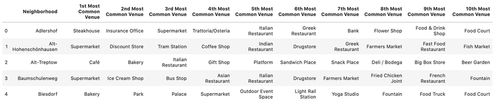

#### 4.4. Neighborhood clusters - using *k-means*

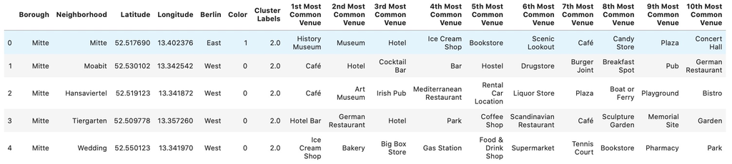

The majority of the neighborhoods belong to two cluster (Cluster Labels 0 and 2 with 88 neighborhoods). The ratio of East neighborhoods per cluster for these is 51.9% or 42.6%. With 96 neighborhoods in total and 45 East Berlin neighborhoods, the expectation value for the 'EastRatio'is 47%. There is one outlier (Cluster Label 1) with only one (West) neighborhood. Cluster 3 shows a higher EastRatio, however only comprises 4 neighborhoods. Besides these clusters, there are no significant East or West clusters.

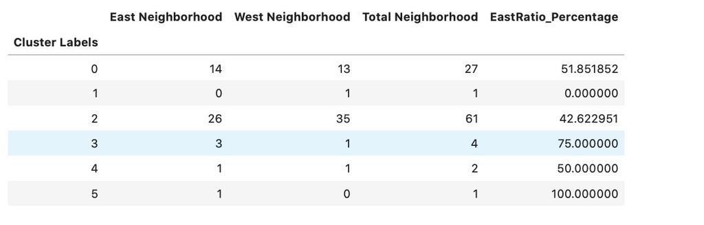

#### 4.5. Map of resulting clusters

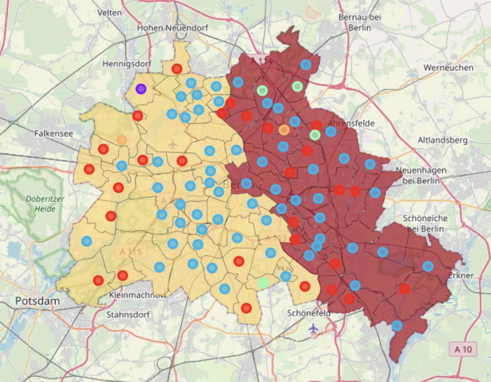

### 6. Conclusion

30 years after the Berlin Wall came down, the city of Berlin seems to be unitied. There are no significant differences between East and West Berlin neighborhoods. An interesting question for further analysis is: How would the results have looked like using data for the venues 20 or 30 years ago?